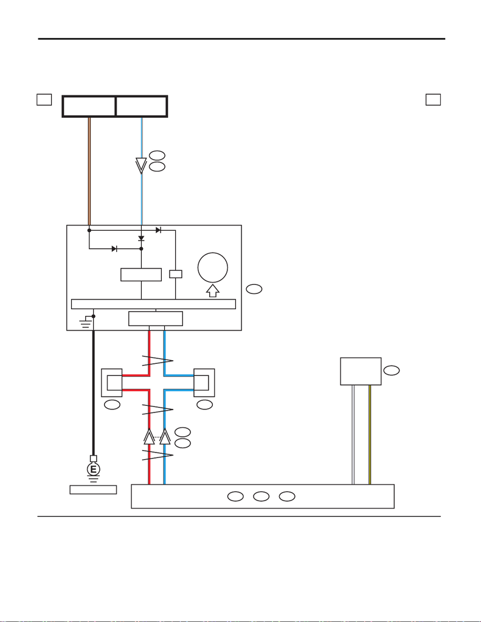

WI-133

Coolant Temperature System

WIRING SYSTEM

14.Coolant Temperature System

A: WIRING DIAGRAM

1. ENGINE TYPE FA

WI-44335

1a 1a

3

38

20

B

BR/W

i10

40

I/F

W/L

BR/W

W/L

W/LW/L

i229

B551

B551

i229

B

33

32

A10

A9 L

R

L

R

L

R

ENGINE

COOLANT

TEMP.

GAUGE

6

7

i233i232

1

1

1

1

1

POWER SUPPLY

CIRCUIT

FB-18

F/B FUSE NO. 7

(B)

FB-12

F/B FUSE NO. 2

(IG)

CAN TRANSCEIVER &

RECEIVER

MICRO COMPUTER

COMBINATION

METER

REF. TO GND [e]

B:

E158

C:

E159

A:

B134

B38

C27

E8

1

2GR

B/Y

ENGINE COOLANT

TEMPERATURE SENSOR

J/CJ/C

: TERMINAL No. OPTIONAL ARRANGEMENT

ECM

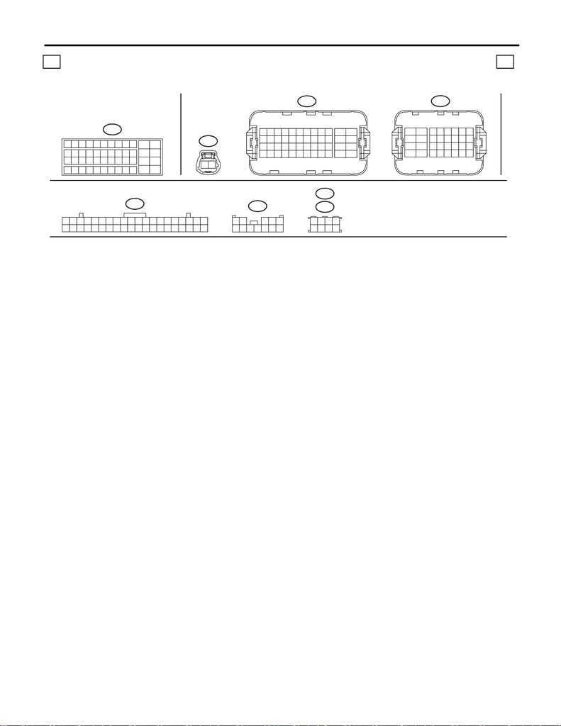

WI-134

Coolant Temperature System

WIRING SYSTEM

LIST OF CONNECTORS

1b 1b

(B)

E8

i229

(GR)

(B)

(BR)

B134A:

i10

C:

E159

B:

E158

10

11 12

23 24

35 36

47 48

3

5

6

7894

12

45

21

33

12

79

10

85

23

11 12

6

19 21 222017

24

35 36

47 48

18

31 33 343229 30

43 45 464441 42

3412

15 1613 14

27 2825 26

39 4037 38

5

7

8

6

3

9

12

4

13

15

16

14

11

10

17 18

25 26

12

21

23

24

22

19 20

29

31

32

30

27 28

11 12

9

10

2

15 1613 14 19

18

20

21 22 23 24 26

25

27 28 29 30 31 32 33 34 35 36 37 38 39 40

17

12 345

6789

10 11 12

i233

i232

78

5

6

34

21

WI-44336

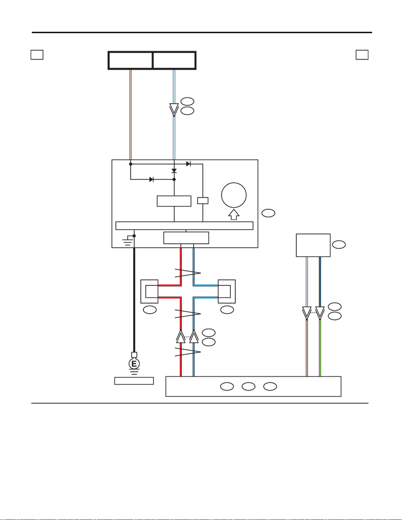

WI-135

Coolant Temperature System

WIRING SYSTEM

2. ENGINE TYPE EJ

WI-44337

2a 2a

3

38

20

B

BR/W

i10

40 W/L

BR/W

W/L

W/LW/L

i229

B551

B

B551

i229

33

32

C17

C28 L

R

L

R

L

R

6

7

B21

E2

12

6

i233i232

1

1

1

1

1

I/F

ENGINE

COOLANT

TEMP.

GAUGE

POWER SUPPLY

CIRCUIT

FB-18

F/B FUSE NO. 7

(B)

FB-12

F/B FUSE NO. 2

(IG)

CAN TRANSCEIVER &

RECEIVER

MICRO COMPUTER

COMBINATION

METER

REF. TO GND [e]

C:

B136

D:

B137

A:

B134

D22

A29

E8

1

2BR/W

Y/G

GR

B/L

ENGINE COOLANT

TEMPERATURE SENSOR

J/CJ/C

: TERMINAL No. OPTIONAL ARRANGEMENT

ECM

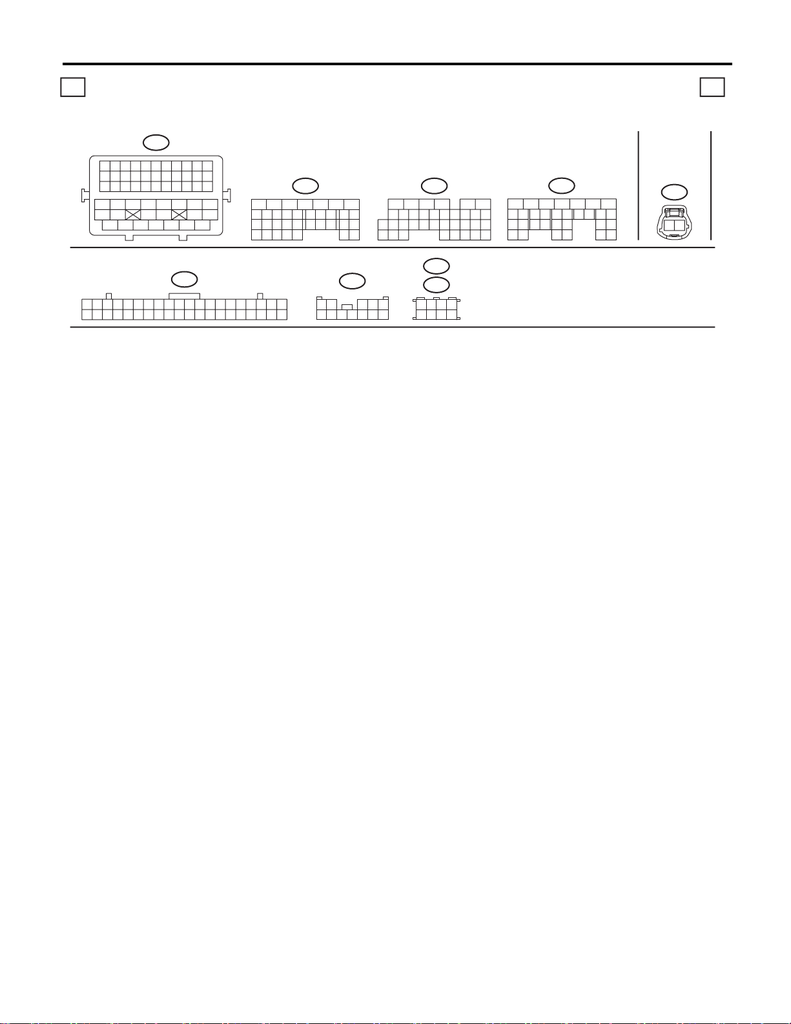

WI-136

Coolant Temperature System

WIRING SYSTEM

LIST OF CONNECTORS

2b 2b

(B)

E8

(B)

B21

i229

B134A: B136C:

B137D:

i10

123456789

10 11

12 13 14 15 16 17 18 19 20 21 22

23 24 25 26 27 28 29 30 31 32 33

34 35

42 43

36 37 38 39

48 49 50 51 52 53 54

40 41

44 45 46 47

18

23

26

24

25

98

15

1413121110

17

16

1234567

19

18

21

20

2322 24 25 26

17

1

23

4

56

27

28 29 30

31 32 33 34 35

798

19

18

20 21

22

23

26

24

25

27

28 29

30 31

98

15

1413121110

17

16

1234567

12

11 12

9

10

2

15 1613 14 19

18

20

21 22 23 24 26

25

27 28 29 30 31 32 33 34 35 36 37 38 39 40

17

12 345

6789

10 11 12

WI-44338

i233

i232

78

5

6

34

21